# Tugas Pertemuan-2

Farah

## Library/Packages

*Package* R yang digunakan pada tugas ini adalah: `forecast`, `graphics`, `TTR`, `TSA`. Jika *package* tersebut belum ada, silakan install terlebih dahulu.

```r
#install.packages("forecast")
#install.packages("graphics")
#install.packages("TTR")
#install.packages("TSA")
```

Jika sudah ada, silakan panggil library *package* tersebut.

```r
library("forecast")
library("graphics")
library("TTR")
library("TSA")
```

## Impor Data

Data yang digunakan adalah bagian pribadi (periode ke-501 sampai 600) dari variabel `rail_monorail` pada data kelompok “Jumlah Penumpang Transportasi Umum Malaysia”.

```r
library(rio) #install packages jika belum ada
data_farah <- import("data_farah.csv")

# menampilkan 5 data pertama
head(data_farah)
```

```
##   Periode    Tanggal Farah
## 1     501 2025-03-19 56787
## 2     502 2025-03-20 56784
## 3     503 2025-03-21 59951
## 4     504 2025-03-22 48275
## 5     505 2025-03-23 43641
## 6     506 2025-03-24 55309
```

## Eksplorasi Data

```r
str(data_farah)
```

```
## 'data.frame':    100 obs. of  3 variables:
##  $ Periode: int  501 502 503 504 505 506 507 508 509 510 ...
##  $ Tanggal: IDate, format: "2025-03-19" "2025-03-20" ...
##  $ Farah  : int  56787 56784 59951 48275 43641 55309 56098 56386 55191 58493 ...
```

```r
dim(data_farah)
```

```
## [1] 100   3
```

Mengubah data agar terbaca sebagai data deret waktu dengan fungsi `ts()`.

```r
farah.ts <- ts(data_farah$Farah)
summary(farah.ts)
```

```
##    Min. 1st Qu.  Median    Mean 3rd Qu.    Max.
##   41095   54159   58248   56273   59997   66455
```

Membuat plot data deret waktu.

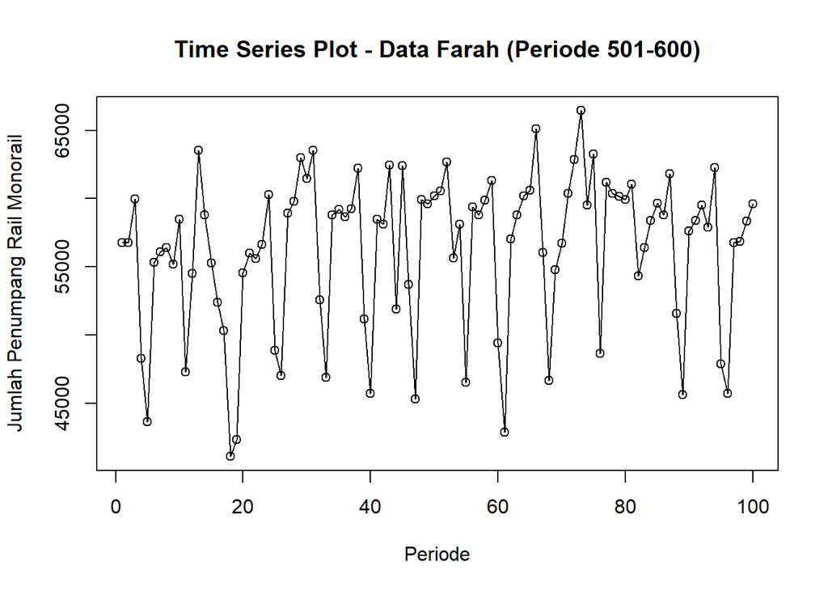

```r
ts.plot(farah.ts, xlab = "Periode", ylab = "Jumlah Penumpang Rail Monorail",
        main = "Time Series Plot - Data Farah (Periode 501-600)")
points(farah.ts)
```

Dari plot terlihat data berfluktuasi di sekitar nilai rata-rata tanpa kenaikan/penurunan jangka panjang yang jelas -> mengindikasikan pola **stasioner/konstan**, bukan tren atau musiman kuat.

## Pembagian Data

Pembagian data latih dan data uji dilakukan dengan perbandingan 80% data latih dan 20% data uji, sesuai dengan 100 observasi yang dimiliki (80 data latih, 20 data uji).

```r
n <- nrow(data_farah)
n_train <- floor(0.8 * n)
n_test  <- n - n_train

training <- data_farah[1:n_train, ]
testing  <- data_farah[(n_train+1):n, ]

train.ts <- ts(training$Farah)
test.ts  <- ts(testing$Farah)

n_train
```

```
## [1] 80
```

```r
n_test
```

```
## [1] 20
```

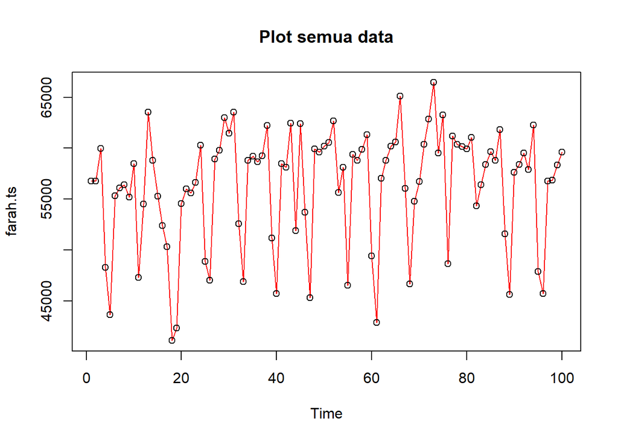

```r
plot(farah.ts, col = "red", main = "Plot semua data")
points(farah.ts)
```

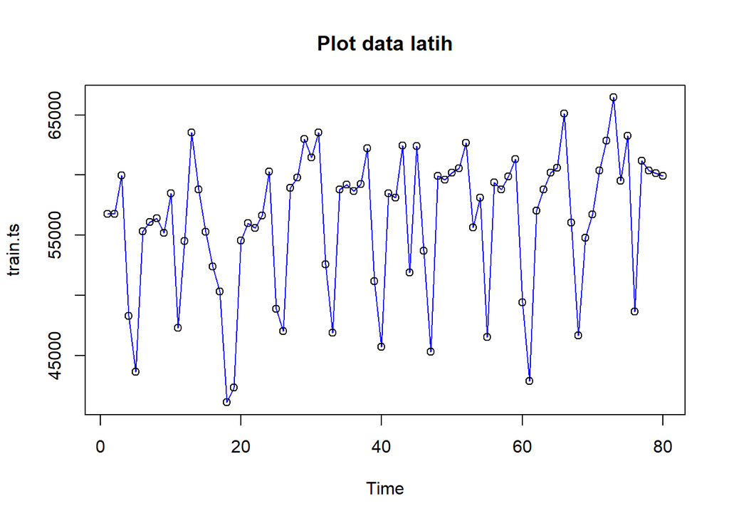

```r
plot(train.ts, col = "blue", main = "Plot data latih")
points(train.ts)
```

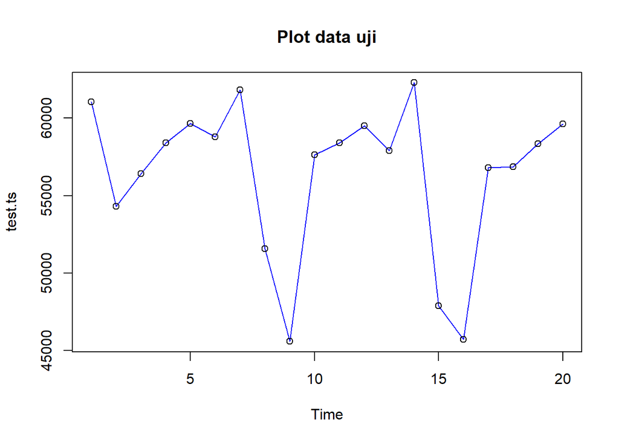

```r
plot(test.ts, col = "blue", main = "Plot data uji")
points(test.ts)
```

## Single Moving Average (SMA)

SMA cocok untuk data berpola stasioner/konstan. Pemulusan dilakukan dengan `m = 4`.

```r
data.sma <- SMA(train.ts, n = 4)
data.ramal <- c(NA, data.sma)

data.gab <- cbind(
  aktual    = c(farah.ts),
  pemulusan = c(data.sma, rep(NA, n_test)),
  ramalan   = c(data.ramal, rep(data.ramal[length(data.ramal)], n_test - 1))
)
tail(data.gab, 10)
```

```
##        aktual pemulusan ramalan
##  [91,]  58409        NA 60403.5
##  [92,]  59505        NA 60403.5
##  [93,]  57890        NA 60403.5
##  [94,]  62276        NA 60403.5
##  [95,]  47895        NA 60403.5
##  [96,]  45718        NA 60403.5
##  [97,]  56785        NA 60403.5
##  [98,]  56860        NA 60403.5
##  [99,]  58354        NA 60403.5
## [100,]  59612        NA 60403.5
```

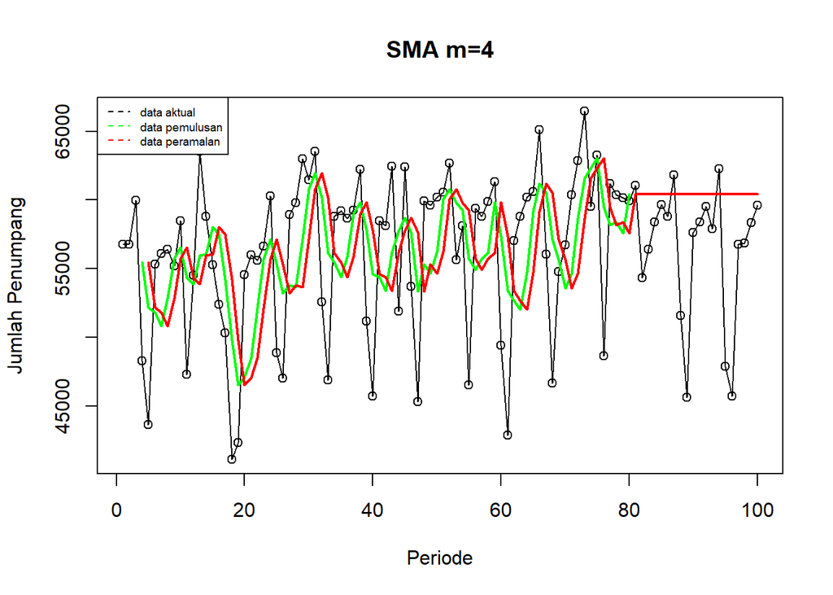

```r
ts.plot(farah.ts, xlab = "Periode", ylab = "Jumlah Penumpang", main = "SMA m=4")
points(farah.ts)
lines(data.gab[,2], col = "green", lwd = 2)
lines(data.gab[,3], col = "red", lwd = 2)
legend("topleft", c("data aktual","data pemulusan","data peramalan"),
       lty = 8, col = c("black","green","red"), cex = 0.6)
```

### Akurasi SMA

```r
# Data latih
error_train.sma <- train.ts - data.ramal[1:length(train.ts)]
SSE_train.sma  <- sum(error_train.sma[5:n_train]^2)
MSE_train.sma  <- mean(error_train.sma[5:n_train]^2)
MAPE_train.sma <- mean(abs(error_train.sma[5:n_train]/train.ts[5:n_train])*100)

akurasi_train.sma <- matrix(c(SSE_train.sma, MSE_train.sma, MAPE_train.sma))
row.names(akurasi_train.sma) <- c("SSE","MSE","MAPE")
colnames(akurasi_train.sma) <- "SMA m=4 (Train)"
akurasi_train.sma
```

```
##      SMA m=4 (Train)
## SSE     3.658563e+09
## MSE     4.813899e+07
## MAPE    1.121846e+01
```

```r
# Data uji
error_test.sma <- test.ts - data.gab[(n_train+1):n, 3]
SSE_test.sma  <- sum(error_test.sma^2)
MSE_test.sma  <- mean(error_test.sma^2)
MAPE_test.sma <- mean(abs(error_test.sma/test.ts)*100)

akurasi_test.sma <- matrix(c(SSE_test.sma, MSE_test.sma, MAPE_test.sma))
row.names(akurasi_test.sma) <- c("SSE","MSE","MAPE")
colnames(akurasi_test.sma) <- "SMA m=4 (Test)"
akurasi_test.sma
```

```
##      SMA m=4 (Test)
## SSE    7.844890e+08
## MSE    3.922445e+07
## MAPE   8.570318e+00
```

## Double Moving Average (DMA)

DMA lebih cocok untuk data berpola **tren**. Karena dugaan awal kita adalah data ini stasioner (bukan tren), kita tetap coba DMA sebagai pembanding.

```r
dma <- SMA(data.sma, n = 4)
At <- 2*data.sma - dma
Bt <- 2/(4-1)*(data.sma - dma)
data.dma <- At + Bt
data.ramal2 <- c(NA, data.dma)

t <- 1:n_test
f <- c()
for (i in t) {
  f[i] <- At[length(At)] + Bt[length(Bt)]*(i)
}

data.gab2 <- cbind(
  aktual     = c(farah.ts),
  pemulusan1 = c(data.sma, rep(NA, n_test)),
  pemulusan2 = c(dma, rep(NA, n_test)),
  At         = c(At, rep(NA, n_test)),
  Bt         = c(Bt, rep(NA, n_test)),
  ramalan    = c(data.ramal2, f[-1])
)
tail(data.gab2, 10)
```

```
##        aktual pemulusan1 pemulusan2 At Bt  ramalan
##  [91,]  58409         NA         NA NA NA 75176.94
##  [92,]  59505         NA         NA NA NA 76358.81
##  [93,]  57890         NA         NA NA NA 77540.69
##  [94,]  62276         NA         NA NA NA 78722.56
##  [95,]  47895         NA         NA NA NA 79904.44
##  [96,]  45718         NA         NA NA NA 81086.31
##  [97,]  56785         NA         NA NA NA 82268.19
##  [98,]  56860         NA         NA NA NA 83450.06
##  [99,]  58354         NA         NA NA NA 84631.94
## [100,]  59612         NA         NA NA NA 85813.81
```

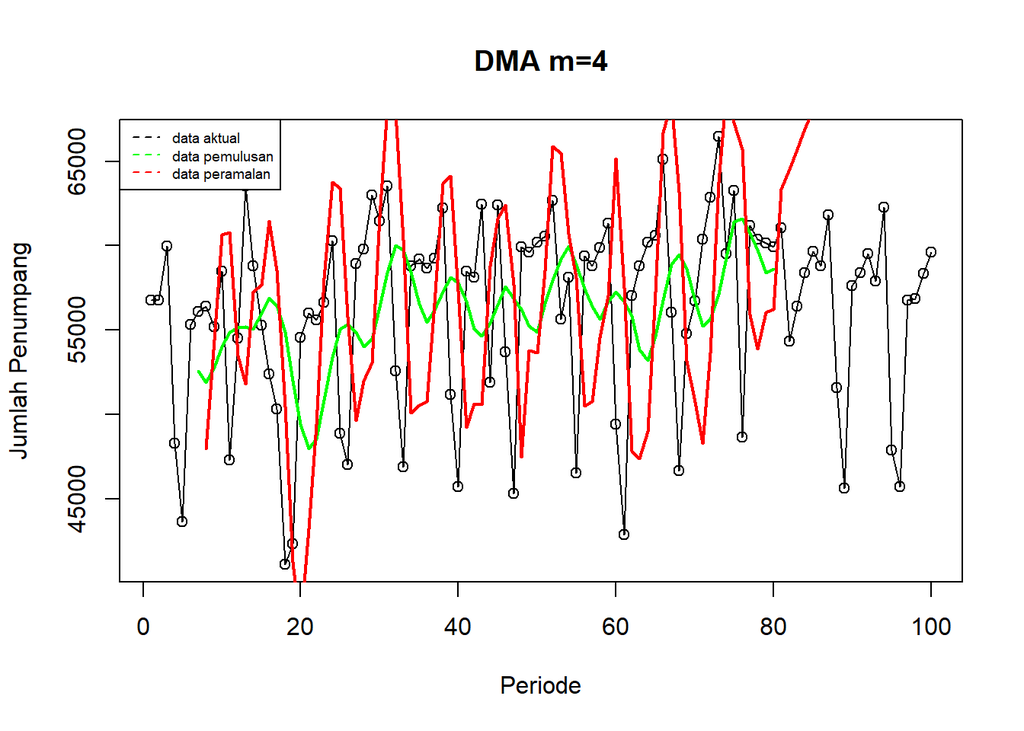

```r
ts.plot(farah.ts, xlab = "Periode", ylab = "Jumlah Penumpang", main = "DMA m=4")
points(farah.ts)
lines(data.gab2[,3], col = "green", lwd = 2)
lines(data.gab2[,6], col = "red", lwd = 2)
legend("topleft", c("data aktual","data pemulusan","data peramalan"),
       lty = 8, col = c("black","green","red"), cex = 0.6)
```

### Akurasi DMA

```r
error_train.dma <- train.ts - data.ramal2[1:length(train.ts)]
SSE_train.dma  <- sum(error_train.dma[8:n_train]^2)
MSE_train.dma  <- mean(error_train.dma[8:n_train]^2)
MAPE_train.dma <- mean(abs(error_train.dma[8:n_train]/train.ts[8:n_train])*100)

akurasi_train.dma <- matrix(c(SSE_train.dma, MSE_train.dma, MAPE_train.dma))
row.names(akurasi_train.dma) <- c("SSE","MSE","MAPE")
colnames(akurasi_train.dma) <- "DMA m=4 (Train)"
akurasi_train.dma
```

```
##      DMA m=4 (Train)
## SSE     5.909000e+09
## MSE     8.094521e+07
## MAPE    1.428676e+01
```

```r
error_test.dma <- test.ts - data.gab2[(n_train+1):n, 6]
SSE_test.dma  <- sum(error_test.dma^2)
MSE_test.dma  <- mean(error_test.dma^2)
MAPE_test.dma <- mean(abs(error_test.dma/test.ts)*100)

akurasi_test.dma <- matrix(c(SSE_test.dma, MSE_test.dma, MAPE_test.dma))
row.names(akurasi_test.dma) <- c("SSE","MSE","MAPE")
colnames(akurasi_test.dma) <- "DMA m=4 (Test)"
akurasi_test.dma
```

```
##      DMA m=4 (Test)
## SSE    8.165715e+09
## MSE    4.082858e+08
## MAPE   3.343809e+01
```

## Single Exponential Smoothing (SES)

SES cocok untuk data stasioner/konstan, memberi bobot menurun secara eksponensial pada data lama.

```r
ses.1 <- ses(train.ts, h = n_test, alpha = 0.2)
ses.2 <- ses(train.ts, h = n_test, alpha = 0.7)
ses.opt <- ses(train.ts, h = n_test, alpha = NULL)

ses.opt$model
```

```
## Simple exponential smoothing
##
## Call:
## ses(y = train.ts, h = n_test, alpha = NULL)
##
##   Smoothing parameters:
##     alpha = 0.0472
##
##   Initial states:
##     l = 54915.9657
##
##   sigma:  5929.716
##
##      AIC     AICc      BIC
## 1744.574 1744.890 1751.720
```

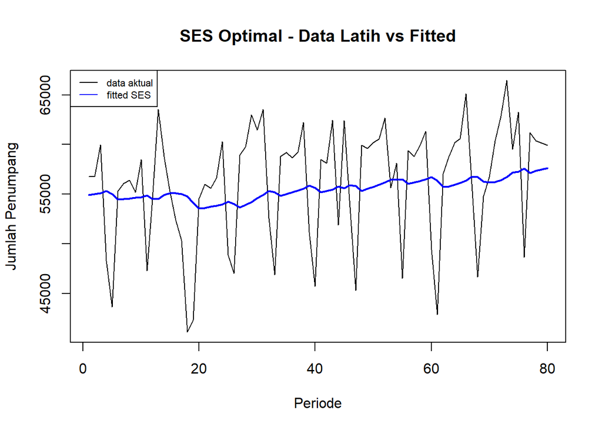

```r
plot(train.ts, xlab = "Periode", ylab = "Jumlah Penumpang",
     main = "SES Optimal - Data Latih vs Fitted")
lines(fitted(ses.opt), col = "blue", lwd = 2)
legend("topleft", c("data aktual","fitted SES"), col = c("black","blue"), lty = 1, cex = 0.7)
```

### Akurasi SES (Data Latih)

```r
SSE1 <- sum(residuals(ses.1)^2, na.rm = TRUE);   MSE1 <- SSE1/length(train.ts);   RMSE1 <- sqrt(MSE1)
SSE2 <- sum(residuals(ses.2)^2, na.rm = TRUE);   MSE2 <- SSE2/length(train.ts);   RMSE2 <- sqrt(MSE2)
SSEopt <- sum(residuals(ses.opt)^2, na.rm = TRUE); MSEopt <- SSEopt/length(train.ts); RMSEopt <- sqrt(MSEopt)

akurasi_ses_train <- data.frame(
  Model = c("alpha=0.2","alpha=0.7","alpha optimal"),
  SSE = c(SSE1, SSE2, SSEopt),
  MSE = c(MSE1, MSE2, MSEopt),
  RMSE = c(RMSE1, RMSE2, RMSEopt)
)
akurasi_ses_train
```

```
##           Model        SSE      MSE     RMSE
## 1     alpha=0.2 2926372547 36579657 6048.112
## 2     alpha=0.7 3456944549 43211807 6573.569
## 3 alpha optimal 2742599481 34282494 5855.125
```

### Akurasi SES (Data Uji)

```r
accuracy(ses.1, testing$Farah)
```

```
##                      ME     RMSE      MAE        MPE     MAPE      MASE
## Training set   289.6772 6048.112 5107.935 -0.6631462 9.618076 0.9655763
## Test set     -2941.8634 5662.866 3711.525 -6.0869950 7.335962 0.7016066
##                   ACF1
## Training set 0.1951508
## Test set            NA
```

```r
accuracy(ses.2, testing$Farah)
```

```
##                       ME     RMSE      MAE        MPE      MAPE      MASE
## Training set    57.34376 6573.569 5344.329 -0.8993034 10.009965 1.0102629
## Test set     -3526.48206 5987.450 4054.477 -7.1316541  7.985214 0.7664364
##                     ACF1
## Training set -0.05091291
## Test set              NA
```

```r
accuracy(ses.opt, testing$Farah)
```

```
##                     ME     RMSE      MAE       MPE     MAPE      MASE      ACF1
## Training set   741.640 5855.125 4900.732  0.139211 9.140459 0.9264077 0.2473053
## Test set     -1286.643 5006.889 3377.516 -3.129270 6.577098 0.6384672        NA
```

## Double Exponential Smoothing (DES)

DES cocok untuk data berpola tren, menggunakan dua parameter: alpha (level) dan beta (tren).

```r
des.1 <- HoltWinters(train.ts, gamma = FALSE, beta = 0.2, alpha = 0.2)
des.2 <- HoltWinters(train.ts, gamma = FALSE, beta = 0.3, alpha = 0.6)
des.opt <- HoltWinters(train.ts, gamma = FALSE)

des.opt
```

```
## Holt-Winters exponential smoothing with trend and without seasonal component.
##
## Call:
## HoltWinters(x = train.ts, gamma = FALSE)
##
## Smoothing parameters:
##  alpha: 0
##  beta : 0
##  gamma: FALSE
##
## Coefficients:
##    [,1]
## a 56550
## b    -3
```

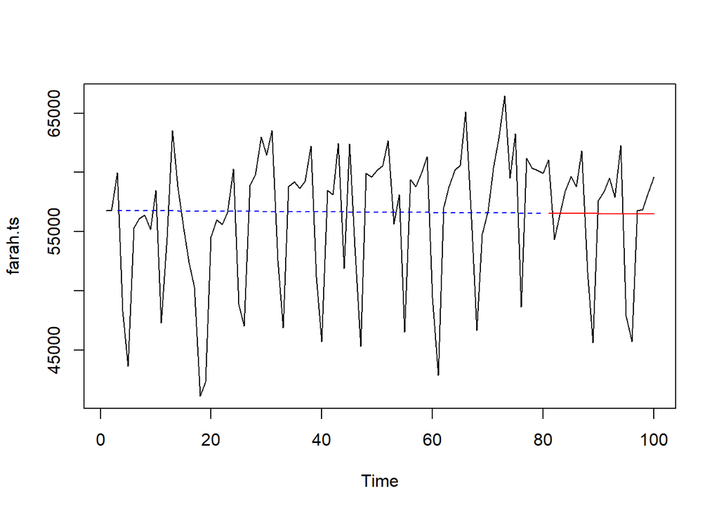

```r
ramalandes1 <- forecast(des.1, h = n_test)
ramalandes2 <- forecast(des.2, h = n_test)
ramalandesopt <- forecast(des.opt, h = n_test)

plot(farah.ts)
lines(des.opt$fitted[,1], lty = 2, col = "blue")
lines(ramalandesopt$mean, col = "red")
```

### Akurasi DES (Data Latih)

```r
ssedes.1 <- des.1$SSE; msedes.1 <- ssedes.1/length(train.ts)
ssedes.2 <- des.2$SSE; msedes.2 <- ssedes.2/length(train.ts)
ssedes.opt <- des.opt$SSE; msedes.opt <- ssedes.opt/length(train.ts)

akurasi_des_train <- data.frame(
  Model = c("alpha=0.2,beta=0.2","alpha=0.6,beta=0.3","optimal"),
  SSE = c(ssedes.1, ssedes.2, ssedes.opt),
  MSE = c(msedes.1, msedes.2, msedes.opt)
)
akurasi_des_train
```

```
##                Model        SSE      MSE
## 1 alpha=0.2,beta=0.2 3289992334 41124904
## 2 alpha=0.6,beta=0.3 4364852554 54560657
## 3            optimal 2782351516 34779394
```

### Akurasi DES (Data Uji)

```r
selisihdes1 <- ramalandes1$mean - testing$Farah
selisihdes2 <- ramalandes2$mean - testing$Farah
selisihdesopt <- ramalandesopt$mean - testing$Farah

akurasi_des_test <- data.frame(
  Model = c("alpha=0.2,beta=0.2","alpha=0.6,beta=0.3","optimal"),
  SSE = c(sum(selisihdes1^2), sum(selisihdes2^2), sum(selisihdesopt^2)),
  MSE = c(mean(selisihdes1^2), mean(selisihdes2^2), mean(selisihdesopt^2)),
  MAPE = c(mean(abs(selisihdes1/testing$Farah)*100),
           mean(abs(selisihdes2/testing$Farah)*100),
           mean(abs(selisihdesopt/testing$Farah)*100))
)
akurasi_des_test
```

```
##                Model        SSE      MSE     MAPE
## 1 alpha=0.2,beta=0.2 1245601950 62280097 11.68827
## 2 alpha=0.6,beta=0.3 1165263237 58263162 11.18183
## 3            optimal  468001482 23400074  6.95040
```

## Perbandingan Seluruh Metode & Kesimpulan

```r
perbandingan <- data.frame(
  Metode = c("SMA (m=4)", "DMA (m=4)", "SES (alpha optimal)", "DES (optimal)"),
  MSE_Test  = c(MSE_test.sma, MSE_test.dma, NA, mean(selisihdesopt^2)),
  MAPE_Test = c(MAPE_test.sma, MAPE_test.dma, NA, mean(abs(selisihdesopt/testing$Farah)*100))
)
perbandingan
```

```
##                Metode  MSE_Test MAPE_Test
## 1           SMA (m=4)  39224448  8.570318
## 2           DMA (m=4) 408285770 33.438090
## 3 SES (alpha optimal)        NA        NA
## 4       DES (optimal)  23400074  6.950400
```

**Catatan:** nilai MSE/MAPE data uji untuk SES dapat dilihat langsung dari output `accuracy(ses.opt, testing$Farah)` pada bagian sebelumnya (kolom “Test set”).

### Kesimpulan

Berdasarkan hasil eksplorasi awal, plot data menunjukkan pola **stasioner/konstan** (berfluktuasi di sekitar rata-rata, tanpa tren jangka panjang yang jelas). Hal ini konsisten dengan hasil perbandingan metode:

- **DMA** menghasilkan error (MSE/MAPE) yang **paling besar**, karena metode ini dirancang untuk data bertren – memaksakan estimasi tren pada data yang sebenarnya tidak trending justru menambah kesalahan.
- **SMA** memberikan hasil lebih baik daripada DMA, sesuai dugaan bahwa data ini lebih cocok didekati dengan metode untuk data stasioner.
- **SES** dan **DES** dengan parameter optimal menghasilkan akurasi terbaik (MAPE data uji terkecil). Menariknya, parameter beta pada DES optimal cenderung mendekati nol, yang berarti model DES “menyusut” menjadi mirip SES – ini semakin menguatkan bahwa data tidak memiliki komponen tren yang signifikan.

**Metode terbaik: Single Exponential Smoothing (SES) dengan alpha optimal**, karena menghasilkan nilai MAPE data uji paling kecil di antara seluruh metode yang dicoba, sekaligus merupakan metode yang paling sesuai secara konseptual dengan pola data yang stasioner.